# Capstone: MovieLens Recommendation System Exploration

December 2024

# Introduction

This study examines the various predictive approaches to creating a movie recommendation system by leveraging the MovieLens dataset, developed by the GroupLens research team at the University of Minnesota is a widely used resource in the field of recommender system research (Harper and Konstan 2015). Recommendation systems are critical tools designed to help users navigate vast collections of items, such as movies, products, or music, by predicting user preferences and delivering personalized suggestions. Platforms like Netflix, Amazon, Spotify, and LinkedIn rely on such systems to enhance user experience and drive engagement. The challenge of building effective recommendation systems lies in the dynamic nature of user preferences, which change over time, making the development of accurate, adaptable models challenging. Originating in 1997 as a successor to DEC’s EachMovie recommender system, MovieLens offers a robust repository of user ratings and timestamps, forming user-item-rating-timestamp tuples that can be useful in personalization research.

By examining traditional methods like basic prediction while accounting for various biases in the data, matrix factorization, and the Extreme Gradient Boosting (XGBOOST) machine learning technique, I aim to identify the most effective algorithms for predicting user ratings. The dataset contains >25 million ratings but here, I will use a version of the dataset that contains 10 million. I evaluate the multiple models based on their predictive accuracy, measured here by their residual mean squared error (RMSE). I also depict the data spatially in map form (**Appendix** below).

This study draws inspiration from a Netflix competition in 2006 that awarded $1 million for improving their recommendation algorithm by 10% (Stone 2009), and applies some of the techniques used by the winning team to the publicly available MovieLens data. Unlike Netflix’s proprietary dataset, the MovieLens data allows open experimentation.

## Analysis

### Visually Explore Dataset

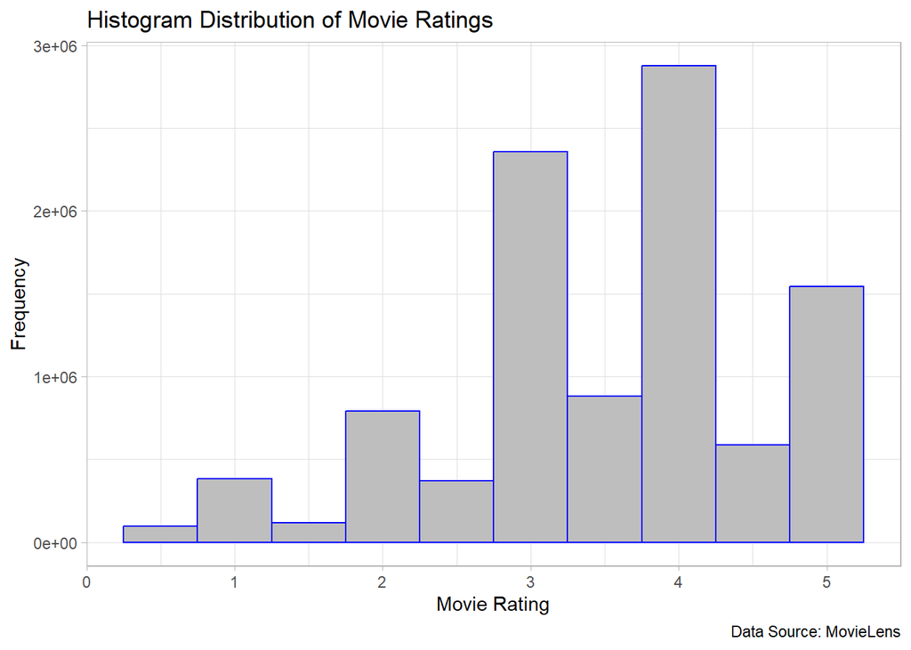

The distribution of movie ratings in the dataset.

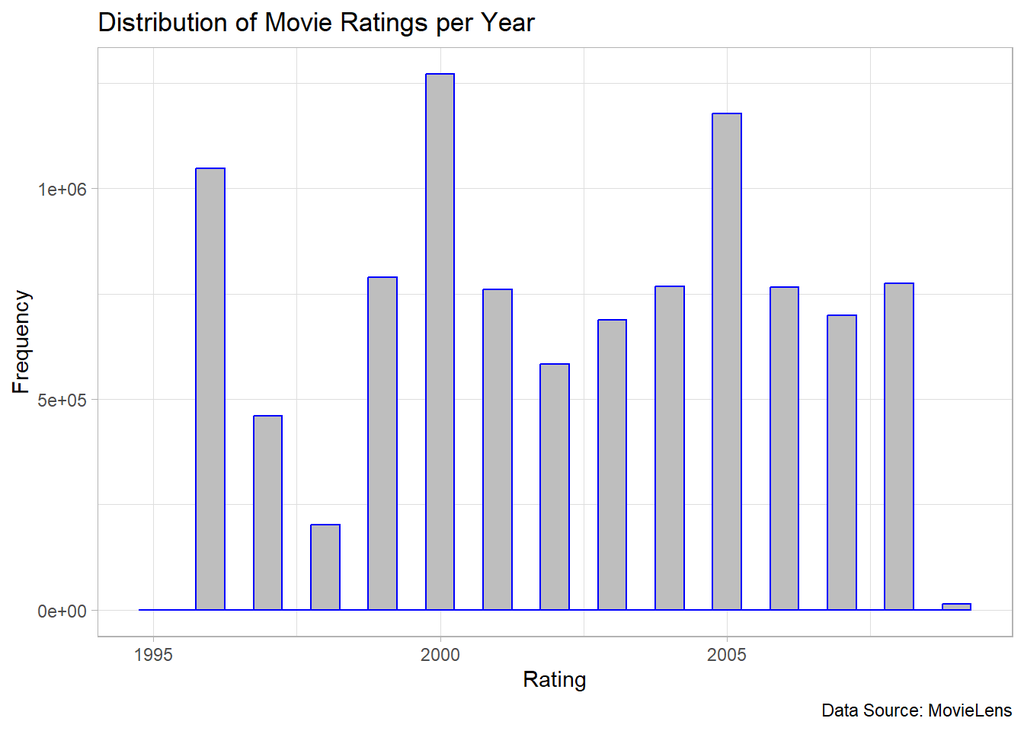

No clear pattern in rating frequency/year.

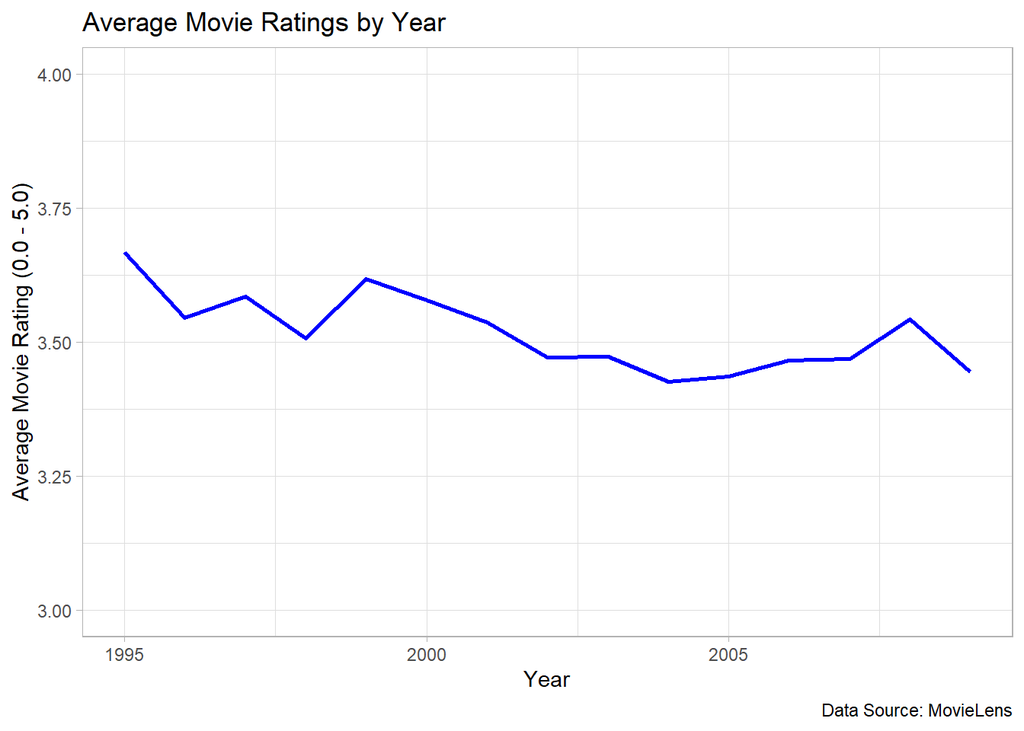

Average movie rating (score, not frequency) decreases slightly over time but inconsequentially.

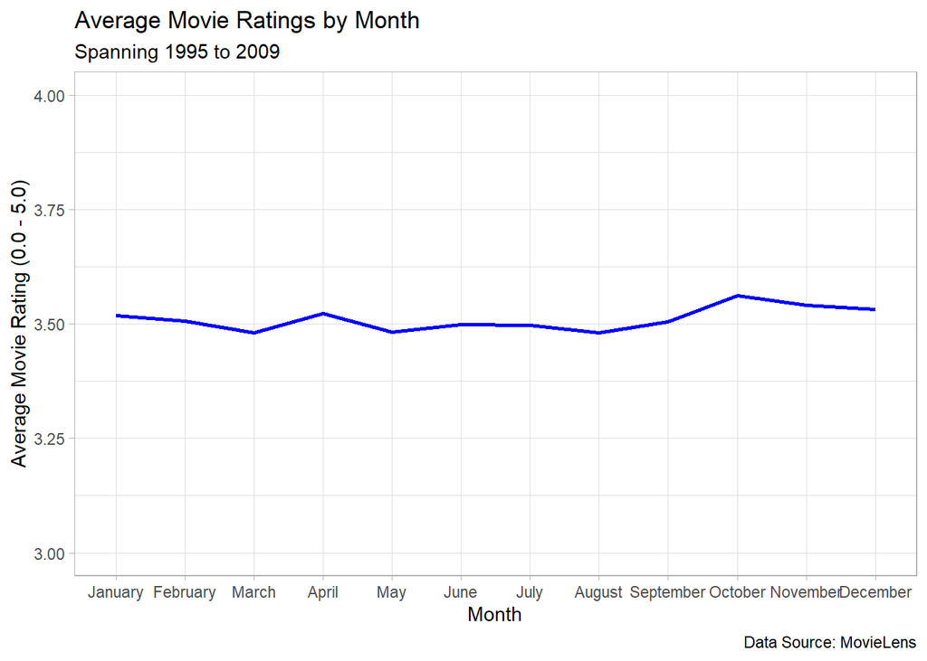

Slight, but relatively unimpactful, pattern in average movie ratings issued by month. Ratings are slightly higher during winter than summer which could be for various sociocultural reasons beyond this study.

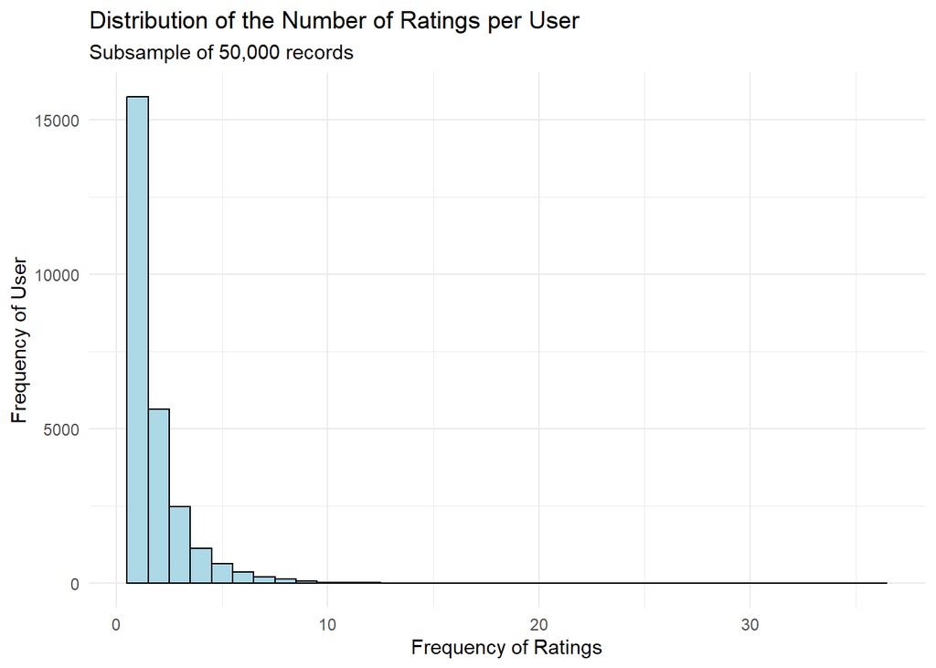

Highly skewed distribution of ratings per user which will likely add bias to predictive analyses.

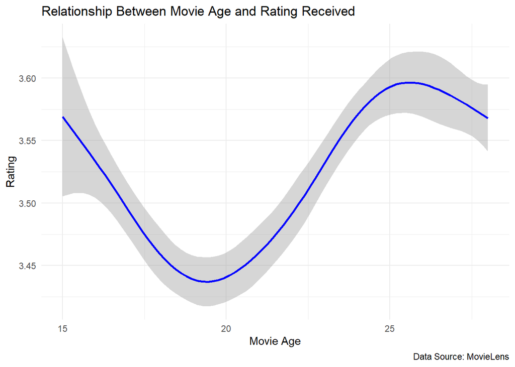

A pattern between movie age and rating received emerges but the data does not yield cultural/film-based evidence of why this may occur.

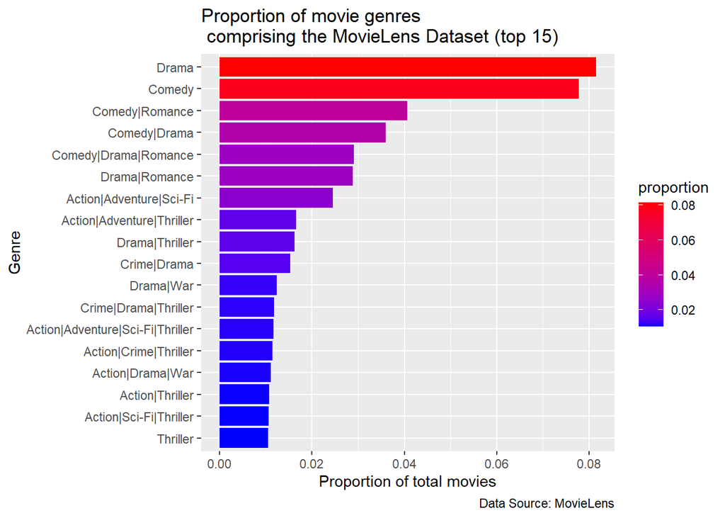

Similar to Figure 5, it is likely that distribution of ratings per genre will influence upcoming predictive analyses.

I examined various approaches to predicting the movie score as measured by RMSE. I began with predicting movie rating simply using the mean and then a vector near the mean (3.4). I then created four subsequent models that account for varying biases such as those introduced by the movie itself, user, genre, or movie’s age.

| Model | RMSE |
| --- | --- |
| Mean Model | 1.0598803 |
| Single Value (3.4) Model | 1.0648649 |
| Movie Bias Model | 0.9388708 |
| Movie+User Bias Model | 0.8530891 |
| Movie+User+Genre Bias Model | 0.8527300 |
| Movie+User+Genre+Age Bias Model | 0.8527019 |